# 13March

## 1. Speeding up functions

- Try simulating the errors just once, `ERR ~ MVN(nrep, 0, Sigma)`, resulting in an `nrep*nsnp` matrix. Let `mexp.zm` be a matrix with `exp.zm` replicated in each row (`nrep` times). Then `zstar = exp.zm + ERR` and we do not have to call `rmvnorm::mvtnorm` for every SNP considered causal.
- The corresponding code from the `corrcov` function is,

```r
ERR = mvtnorm:::rmvnorm(nrep, rep(0, ncol(Sigma)), Sigma)
pp_ERR = function(Zj, nrep, Sigma) {
    exp.zm = Zj %*% Sigma
    mexp.zm = matrix(exp.zm, nrep, length(Zj), byrow = TRUE)  # matrix of Zj replicated in each row
    zstar = mexp.zm + ERR
    bf = 0.5 * (log(1 - r) + (r * zstar^2))
    denom = coloc:::logsum(bf)
    pp.tmp = exp(bf - denom)
    pp.tmp/rowSums(pp.tmp)
}
```

- This method possibly makes the results dependent between different SNPs (only one ERR matrix is used - they have the same errors), but this should be ok for large numbers of simulations.
- Check that the original method, `zstar = rmvnorm(nrep, exp.zm, Sigma)`, is equivalent to this new method, `zstar = exp.zm + ERR`, where `ERR ~ N(0, Sigma)`.

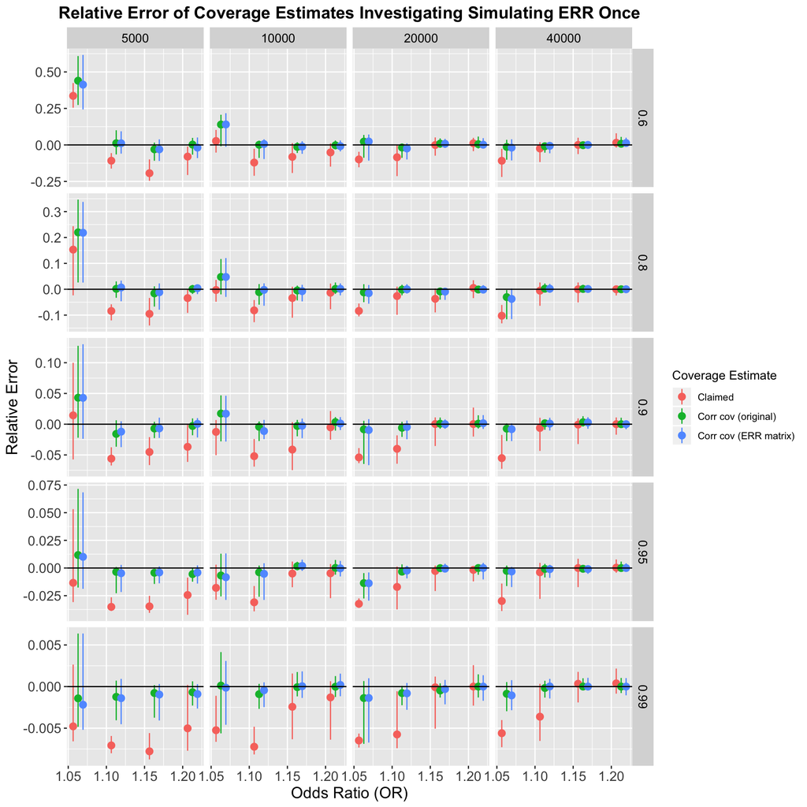

- Yep, I’ve convinced myself that they’re the same.
- BUT, I was looking at some old code and we tried this at some stage:

```r
ERR = rmvnorm(nrep, rep(0, ncol(Sigma)), Sigma)
simzstar <- function(Zj) {
    mZj = matrix(Zj, nrep, length(Zj), byrow = TRUE)  # matrix of Zj replicated in each row
    ii = which(Zj != 0)  # currently considered causal snp
    mZj[, ii] = mZj[, ii] - ERR[, ii]
    exp.zm = mZj %*% Sigma
    exp.zm + ERR
}
```

- This gives slightly different `zstars` and maintains the value of $\mu$ at the causal variant in the `zstar` vectors. Which one should I be using?

## 2. Compare `corrcov` and `corrcov_bhat` functions

- Check that the results using `corrcov` ($Z$-scores, MAFs) and `corrcov_bhat` (`bhat` and $V$) are accurate.
- Should we be concerned by the variability of these estimates, considering the only variability between these is when we simulate the errors using `rmvnorm`? (10000 simulations)

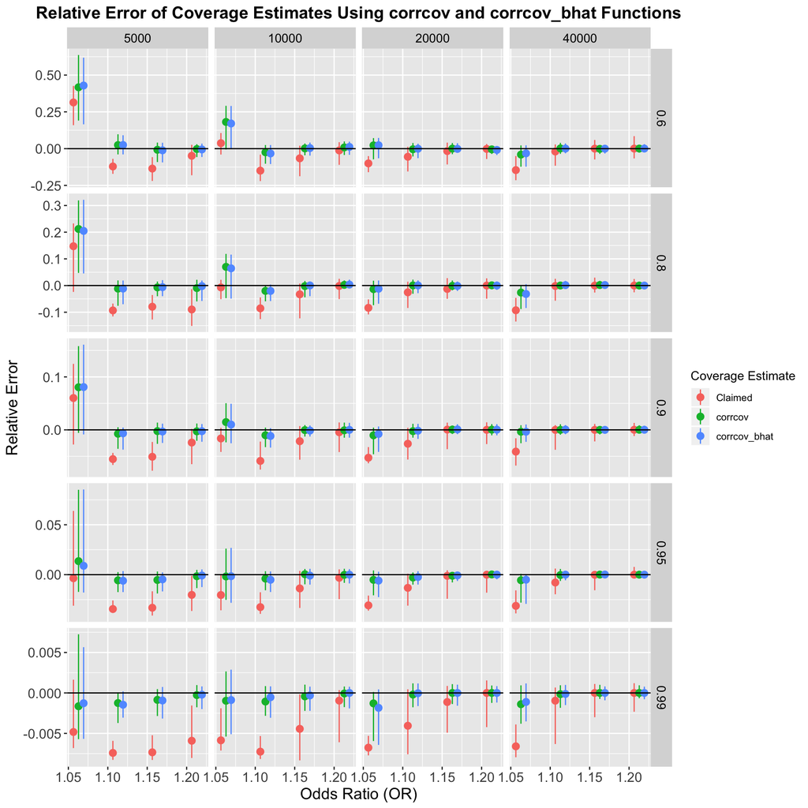

## 3. Obtaining required threshold

- Aim: Find the smallest threshold needed such that the corrected coverage is above the desired coverage.
- Last week, I tried a method whereby I systematically added/removed variants from the set. But, the corrected coverage is only indirectly a function of the snps in the set and is more directly a function of the threshold used to define that set. Therefore, I now consider a method that varies the threshold.
- The following function uses the bracketing bisection method to find the ‘root’ of an equation and therefore the smallest threshold s.t. we exceed the desired coverage.

```r
#' corrected_cs
#'
#' @param z Z-scores
#' @param f Minor allele frequencies
#' @param N0 Number of controls
#' @param N1 Number of cases
#' @param Sigma Correlation matrix of SNPs
#' @param lower Lower threshold
#' @param upper Upper threshold
#' @param desired.cov The desired coverage of the causal variant in the credible set
#' @param acc Accuracy of corrected coverage to desired coverage (default = 0.005)
#' @param max.iter Maximum iterations (default = 20)
#'
#' @return list of variants in credible set, required threshold, the corrected coverage and the size of the credible set
#' @export
corrected_cs <- function(z, f, N0, N1, Sigma, lower, upper, desired.cov, acc = 0.005, max.iter = 20){
  # lower <- 2*desired.cov - 1
  # upper <- min(1,desired.cov + 0.05)
  s = N1/(N0+N1) # proportion of cases
  V = 1/(2 * (N0+N1) * f * (1 - f) * s * (1 - s))
  W = 0.2
  r <- W^2/(W^2 + V)
  pp <- ppfunc(z, V = V) # pp of system in question
  muhat = est_mu(z, f, N0, N1)
  nsnps = length(pp)
  temp = diag(x = muhat, nrow = nsnps, ncol = nsnps)
  zj = lapply(seq_len(nrow(temp)), function(i) temp[i,]) # nsnp zj vectors for each snp considered causal
  nrep = 1000

  # simulate ERR matrix
  ERR = mvtnorm:::rmvnorm(nrep, rep(0,ncol(Sigma)), Sigma)
  pp_ERR = function(Zj){
    exp.zm = Zj %*% Sigma
    mexp.zm = matrix(exp.zm, nrep, length(Zj), byrow=TRUE) # matrix of Zj replicated in each row
    zstar = mexp.zm+ERR
    bf = 0.5 * (log(1 - r) + (r * zstar^2))
    denom = coloc:::logsum(bf)  # logsum(x) = max(x) + log(sum(exp(x - max(x)))) so sum is not inf
    pp.tmp = exp(bf - denom)  # convert back from log scale
    pp.tmp / rowSums(pp.tmp)
  }
  # simulate pp systems
  pps <- mapply(pp_ERR, zj, SIMPLIFY = FALSE)

  n_pps <- length(pps)
  args <- 1:length(pp)

  f <- function(thr){ # finds the difference between corrcov and desired.cov
    d5 <- lapply(1:n_pps, function(x) {
      credsetC(pps[[x]], CV = rep(args[x], dim(pps[[x]])[1]), thr = thr)
    })
    prop_cov <- lapply(d5, prop_cov) %>% unlist()
    sum(prop_cov * pp) - desired.cov
  }

  # initalize
  N=1
  fa = f(lower)
  fb = f(upper)

  if (fa * fb > 0) {
    stop("No root in range, increase window")
  } else {
    fc = min(fa, fb)
    while (N <= max.iter & !dplyr::between(fc, 0, acc)) {
      c = lower + (upper-lower)/2
      fc = f(c)
      print(paste("thr: ", c, ", cov: ", desired.cov + fc))

      if (fa * fc < 0) {
        upper = c
        fb = fc
      } else if (f(upper) * fc < 0) {
        lower = c
        fa = fc
      }
      N = N + 1
    }
    # df <- data.frame(req.thr = c, corr.cov = desired.cov + fc)
  }
  o <- order(pp, decreasing = TRUE)  # order index for true pp
  cumpp <- cumsum(pp[o])  # cum sums of ordered pps
  wh <- which(cumpp > c)[1]  # how many needed to exceed thr
  list(credset = names(pp)[o[1:wh]], req.thr = c, corr.cov = desired.cov + fc, size = cumpp[wh])
}
```

- I have added this to the R package and included a vignette of how to use it [here](https://annahutch.github.io/corrcoverage/articles/New-Credible-Set.html)

#### Is the true coverage of the new credible set approx. 0.8?

- I ran some simulations using this `corrected_cs` function. The first plot shows the true empirical coverage of the simulated credible sets grouped by true $\mu$ value (approx. 500-1000 simulations in each group).
  - Left: The original 80% credible sets obtained using the standard Bayesian approach
  - Right: The new credible sets obtained using the `corrected_cs` function (which finds the required threshold and uses the standard Bayesian approach with this new threshold).

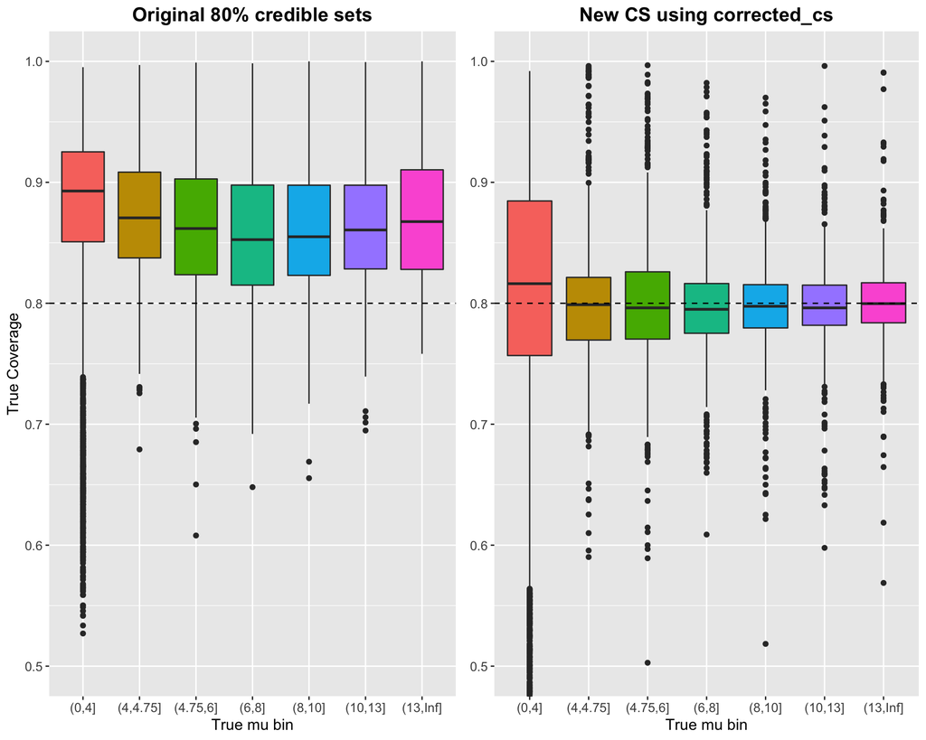

- The function works well at providing a new credible set with nearer to the desired coverage, however I am wary of how many are below 0.8 and the variability of the true coverage estimates. These are artefacts of our correction (since all the corrected coverages values for the points on the right plot are between 0.8 and 0.8005)
- Side note: Why is there a ‘dip’ in the left plot?

#### Relative Error

- The following plots are to visualise the relative error of the corrected and claimed coverage estimates of the original credible sets and the new ones obtained using the `corrected_cs` function.
- Firstly, for the original credible sets:

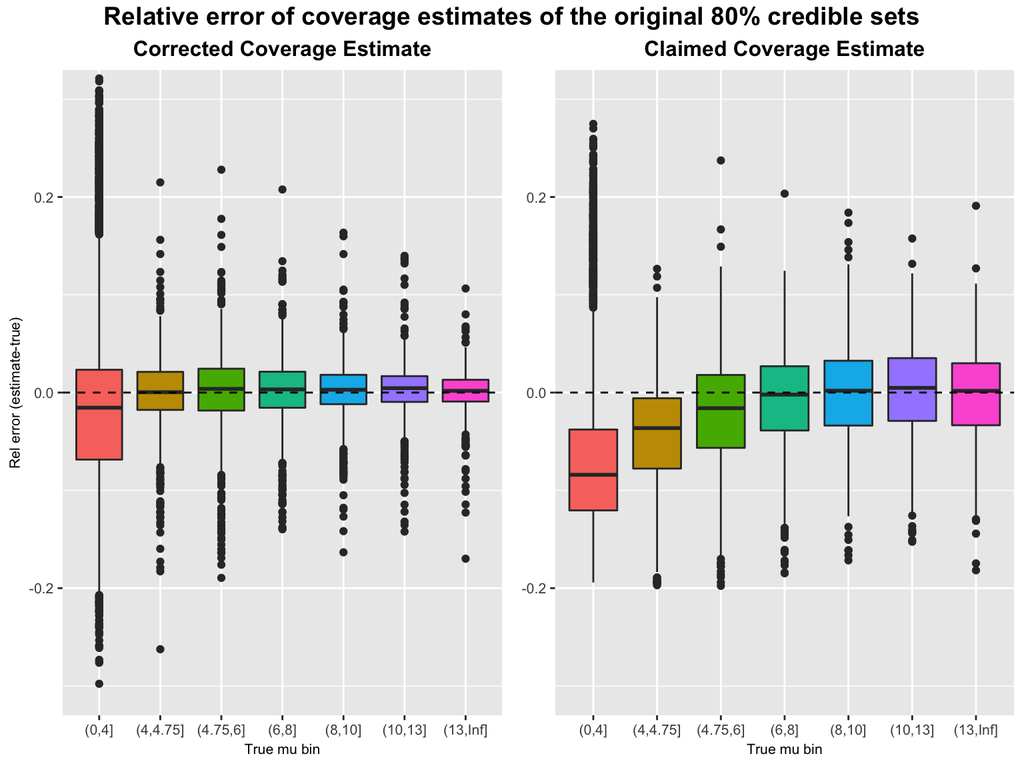

- Secondly, for the new credible sets:

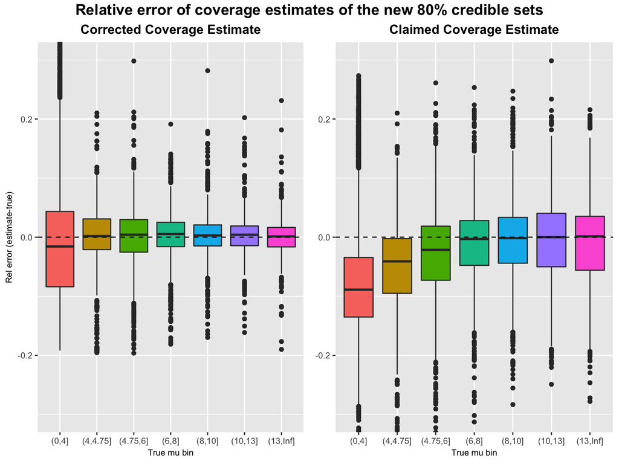

#### Differences in nvar

- The table below shows the summary statistics for the difference between the number of variants in the original 80% credible set and the new 80% credible set (using the `corrected_cs` function). I.e. how many variants have been removed.
- Obviously fewer variants are removed in high power scenarios as the original credible set often only has 1 variant in it.
- Infact, where we would use fine-mapping there is often only one variant in the credible set anyway so most of the time the credible set will stay the same? I think that our correction method will work best in high linkage disequilibrium cases where there are many variants in the set.

```
##         bin       mean median low.error high.error
## 1:    (0,4] 11.4607724      8         1         22
## 2: (4,4.75]  4.5208597      1         1          3
## 3: (4.75,6]  2.2918862      1         1          1
## 4:    (6,8]  0.8317152      1         0          1
## 5:   (8,10]  0.6227390      1         0          1
## 6:  (10,13]  0.6385542      1         0          1
## 7: (13,Inf]  0.5674419      1         0          1
```

## 4. T1D

#### Method (case-control)

1. Single-SNP logistic regression for T1D versus additive genotype score (0, 1 or 2 risk alleles), adjusted for sex and regions in the UK.
2. Used forward stepwise analyses to investigate secondary independent associations in each region. I.e. fit a new logistic regression model with the most significantly associated SNP as a covariate. Repeat, building up the covariates in the model until no more SNPs are significant.
3. For each index SNP ($i$), consider all SNPs within a 50-kb window and calculate the ABFs comparing models containing the index SNP $i$, and each alternative SNP $j$. Where,
   $$-2log(ABF_{ij})=BIC_i-BIC_j$$
4. Estimate the probability that any individual SNP $j$ is the causal variant responsible for that signal by,
   $$PP_j=\frac{BIC_j}{sum(BIC_j)}$$
5. Create 99% credible sets of SNPs by ordering these and cumulatively summing until the sum exceeds 0.99.
6. Further modified these credible sets by
   - Expanding the set: Include neighbouring SNPs which did not pass genotyping on the Immunochip and are in high LD with a SNP in the credible set.
   - Filtering: Based on those which overlapped with enhancers in tissues that showed enrichment and those that were nonsynonymous.

Problems:

- My calculated posterior probabilities do not match those in the paper. Perhaps due to cutting out SNPs not in LD matrix, rounding or the method used to calculate pps in the paper. Why are they looking at ABF comparing index SNP causal vrs each of the others rather than ABF comparing each SNP causal vrs the null?
- Getting this error: In mvtnorm:::rmvnorm(nrep, rep(0, ncol(Sigma)), Sigma) : sigma is numerically not positive semidefinite.
- Anyhow, I have ran an array job that finds the corrected coverage of the 99% credible sets from the T1D data and (if possible) finds a new credible set with corrected coverage >= 0.99 using the `corrcoverage` package.
  - their_cs_nvar: The number of variants in the credible set reported in the paper
  - our_cs_nvar: The number of variants in the credible set I found by following the standard Bayesian method
  - our_cs_corrcov: The corrected coverage estimate of the credible set using the standard Bayesian approach
  - new_cs_nvar: The number of variants in the new credible set found using the `corrected_cs` function
  - new_corrcov: The corrected coverage estimate of the new credible set

```
##     index_SNP their_cs_nvar our_cs_nvar our_cs_corrcov new_cs_nvar new_corrcov
## 1  rs10277986            26          11      0.9732795          17   0.9903420
## 2  rs11203202             5           4      0.9960134           4   0.9904442
## 3  rs11954020           136          83      0.9941234          74   0.9904929
## 4  rs12416116             7           6      0.9902935           5   0.9900865
## 5  rs12453507           112          65      0.9921685          63   0.9904078
## 6  rs12927355            41          20      0.9693932          24   0.9904093
## 7  rs13415583           139          92      0.9889096          97   0.9900088
## 8   rs1456988            40          26      0.9915964          26   0.9904314
## 9    rs151234             0          10      0.9848938          20   0.9904777
## 10  rs1538171           154          87      0.9701159         101   0.9904821
## 11  rs1615504            40          26      0.9920699          25   0.9904854
## 12  rs1893217            35          11      0.9478510          32   0.9900666
## 13   rs193778           102          23      0.9932024          24   0.9903892
## 14  rs2111485             4           4      0.9822731           4   0.9901479
```

[output cut: 23 more lines]

- It seems that our method works well at increasing the number of variants in the set when the corrected coverage estimate is too low (e.g. rs61839660) and removing variants from the set when the corrected coverage estimate is too high (e.g. rs11954020).

## 5. Next Steps + Qs

- I worry that we are giving users a sort of ultimatum, “use the claimed coverage or use our corrected coverage”. It would be good if we could provide them with an indication of how good/bad the claimed and corrected coverage estimates are. Of course, they could look at our relative error plots and see which facet most closely matches their sample size/ OR/ threshold but I think it would be better to provide something more concrete. Perhaps a confidence interval for each estimate or some sort of ‘confidence score’ based on muhat/sample sizes etc.
- Our package should also report an error/ warning if they shouldn’t be using fine-mapping or my correction method. I think the best way to implement this is to set a cut-off on the minimum muhat value required.
- Investigate how we can reduce the variability in corrected coverage estimates. The method is extemely fast now, so perhaps we could calculate many corrected coverage estimates and take the average of these?
- Slightly confused about $OR$ in our simulations. We fix it at a value, yet in the real data each SNP has an OR value associated with it (allowing us to calculate bhat).
- Talk through Rob’s suggestions.